# balance Quickstart (CBPS): Analyzing and adjusting the bias on a simulated toy dataset

'balance' is a Python package that is maintained and released by the Core Data Science Tel-Aviv team in Meta. 'balance' performs and evaluates bias reduction by weighting for a broad set of experimental and observational use cases.

Although balance is written in Python, you don't need a deep Python understanding to use it. In fact, you can just use this notebook, load your data, change some variables and re-run the notebook and produce your own weights!

This quickstart demonstrates re-weighting specific simulated data, but if you have a different usecase or want more comprehensive documentation, you can check out the comprehensive balance tutorial.

## Analysis

There are four main steps to analysis with balance:

- load data
- check diagnostics before adjustment
- perform adjustment + check diagnostics
- output results

Let's dive right in!

## Example dataset

The following is a toy simulated dataset.

```python
%matplotlib inline

import plotly.offline as offline
offline.init_notebook_mode()

from balance import load_data
```

```
INFO (2026-08-15 06:46:23,981) [__init__/<module> (line 77)]: Using balance version 0.23.0
```

[output not shown]

```python
target_df, sample_df = load_data()

print("target_df: \n", target_df.head())
print("sample_df: \n", sample_df.head())
```

```
target_df:
        id gender age_group     income  happiness
0  100000   Male       45+  10.183951  61.706333
1  100001   Male       45+   6.036858  79.123670
2  100002   Male     35-44   5.226629  44.206949
3  100003    NaN       45+   5.752147  83.985716
4  100004    NaN     25-34   4.837484  49.339713
sample_df:
   id  gender age_group     income  happiness
0  0    Male     25-34   6.428659  26.043029
1  1  Female     18-24   9.940280  66.885485
2  2    Male     18-24   2.673623  37.091922
3  3     NaN     18-24  10.550308  49.394050
4  4     NaN     18-24   2.689994  72.304208
```

```python
target_df.head().round(2).to_dict()
# sample_df.shape
```

```
{'id': {0: '100000', 1: '100001', 2: '100002', 3: '100003', 4: '100004'},
 'gender': {0: 'Male', 1: 'Male', 2: 'Male', 3: nan, 4: nan},
 'age_group': {0: '45+', 1: '45+', 2: '35-44', 3: '45+', 4: '25-34'},
 'income': {0: 10.18, 1: 6.04, 2: 5.23, 3: 5.75, 4: 4.84},
 'happiness': {0: 61.71, 1: 79.12, 2: 44.21, 3: 83.99, 4: 49.34}}
```

In practice, one can use pandas loading function(such as `read_csv()`) to import data into the DataFrame objects `sample_df` and `target_df`.

# Load data into a Sample object

The first thing to do is to import the `Sample` class from balance. All of the data we're going to be working with, sample or population, will be stored in objects of the `Sample` class.

```python
from balance import Sample
```

Using the Sample class, we can fill it with a "sample" we want to adjust, and also a "target" we want to adjust towards.

We turn the two input pandas DataFrame objects we created (or loaded) into a balance.Sample objects, by using the `.from_frame()`

```python
sample = Sample.from_frame(sample_df, outcome_columns=["happiness"])
target = Sample.from_frame(target_df, outcome_columns=["happiness"])
```

```
WARNING (2026-08-15 06:46:24,024) [input_validation/guess_id_column (line 336)]: Guessed id column name id for the data
```

```
WARNING (2026-08-15 06:46:24,036) [sample_frame/from_frame (line 380)]: No weights passed. Adding a 'weight' column and setting all values to 1
```

```
WARNING (2026-08-15 06:46:24,038) [input_validation/guess_id_column (line 336)]: Guessed id column name id for the data
```

```
WARNING (2026-08-15 06:46:24,052) [sample_frame/from_frame (line 380)]: No weights passed. Adding a 'weight' column and setting all values to 1
```

If we use the `.df` property call, we can see the DataFrame stored in sample. We can see how we have a new weight column that was added (it will all have 1s) in the importing of the DataFrames into a `balance.Sample` object.

```python
sample.df.info()
```

```
<class 'pandas.DataFrame'>
RangeIndex: 1000 entries, 0 to 999
Data columns (total 6 columns):
 #   Column     Non-Null Count  Dtype
---  ------     --------------  -----
 0   id         1000 non-null   str
 1   gender     912 non-null    str
 2   age_group  1000 non-null   str
 3   income     1000 non-null   float64
 4   happiness  1000 non-null   float64
 5   weight     1000 non-null   float64
dtypes: float64(3), str(3)
memory usage: 47.0 KB
```

We can get a quick overview text of each Sample object, but just calling it.

Let's take a look at what this produces:

```python
sample
```

```
(balance.sample_class.Sample)

        balance Sample object
        1000 observations x 3 variables: gender,age_group,income
        id_column: id, weight_column: weight,
        outcome_columns: happiness
```

```python
target
```

```
(balance.sample_class.Sample)

        balance Sample object
        10000 observations x 3 variables: gender,age_group,income
        id_column: id, weight_column: weight,
        outcome_columns: happiness
```

Next, we combine the sample object with the target object. This is what will allow us to adjust the sample to the target.

```python
sample_with_target = sample.set_target(target)
```

Looking on `sample_with_target` now, it has the target atteched:

```python
sample_with_target
```

```
(balance.sample_class.Sample)

        balance Sample object with target set
        1000 observations x 3 variables: gender,age_group,income
        id_column: id, weight_column: weight,
        outcome_columns: happiness

            target:

	        balance Sample object
	        10000 observations x 3 variables: gender,age_group,income
	        id_column: id, weight_column: weight,
	        outcome_columns: happiness

            3 common variables: gender,age_group,income
```

# Pre-Adjustment Diagnostics

We can use `.covars()` and then followup with `.mean()` and `.plot()` (barplots and qqplots) to get some basic diagnostics on what we got.

We can see how:

```python
print(sample_with_target.covars().mean().T)
```

```
source                     self     target
_is_na_gender[T.True]  0.088000   0.089800
age_group[T.25-34]     0.300000   0.297400
age_group[T.35-44]     0.156000   0.299200
age_group[T.45+]       0.053000   0.206300
gender[Female]         0.268000   0.455100
gender[Male]           0.644000   0.455100
gender[_NA]            0.088000   0.089800
income                 6.297302  12.737608
```

```python
print(sample_with_target.covars().asmd().T)
```

```
source                  self
age_group[T.25-34]  0.005688
age_group[T.35-44]  0.312711
age_group[T.45+]    0.378828
gender[Female]      0.375699
gender[Male]        0.379314
gender[_NA]         0.006296
income              0.494217
mean(asmd)          0.326799
```

```python
print(sample_with_target.covars().asmd(aggregate_by_main_covar = True).T)
```

```
source          self
age_group   0.232409
gender      0.253769
income      0.494217
mean(asmd)  0.326799
```

```python
sample_with_target.covars().plot()
```

[interactive chart not shown]

# Adjusting Sample to Population (ipw and cbps)

Next, we adjust the sample to the target. The default method to be used is 'ipw' (which uses inverse probability/propensity weights, after running logistic regression with lasso regularization).

```python
# Using ipw to fit survey weights
adjusted_ipw = sample_with_target.adjust()
```

```
INFO (2026-08-15 06:46:24,900) [ipw/ipw (line 735)]: Starting ipw function
```

```
INFO (2026-08-15 06:46:24,905) [adjustment/apply_transformations (line 435)]: Adding the variables: []
```

```
INFO (2026-08-15 06:46:24,906) [adjustment/apply_transformations (line 436)]: Transforming the variables: ['gender', 'age_group', 'income']
```

```
INFO (2026-08-15 06:46:24,916) [adjustment/apply_transformations (line 472)]: Final variables in output: ['gender', 'age_group', 'income']
```

```
INFO (2026-08-15 06:46:25,035) [ipw/ipw (line 813)]: Building model matrix
```

```
INFO (2026-08-15 06:46:25,035) [ipw/ipw (line 814)]: The formula used to build the model matrix: ['income + gender + age_group + _is_na_gender']
```

```
INFO (2026-08-15 06:46:25,036) [ipw/ipw (line 815)]: The number of columns in the model matrix: 16
```

```
INFO (2026-08-15 06:46:25,036) [ipw/ipw (line 816)]: The number of rows in the model matrix: 11000
```

```
INFO (2026-08-15 06:46:44,977) [ipw/ipw (line 1012)]: Done with sklearn
```

```
INFO (2026-08-15 06:46:44,979) [ipw/ipw (line 1014)]: max_de: None
```

```
INFO (2026-08-15 06:46:44,979) [ipw/ipw (line 1036)]: Starting model selection
```

```
INFO (2026-08-15 06:46:44,982) [ipw/ipw (line 1092)]: Chosen lambda: 0.041158338186664825
```

```
INFO (2026-08-15 06:46:44,983) [ipw/ipw (line 1109)]: Proportion null deviance explained 0.172637976731583
```

```python
adjusted_cbps = sample_with_target.adjust(method = "cbps")
```

```
INFO (2026-08-15 06:46:44,999) [cbps/cbps (line 535)]: Starting cbps function
```

```
INFO (2026-08-15 06:46:45,001) [adjustment/apply_transformations (line 435)]: Adding the variables: []
```

```
INFO (2026-08-15 06:46:45,002) [adjustment/apply_transformations (line 436)]: Transforming the variables: ['gender', 'age_group', 'income']
```

```
INFO (2026-08-15 06:46:45,012) [adjustment/apply_transformations (line 472)]: Final variables in output: ['gender', 'age_group', 'income']
```

```
INFO (2026-08-15 06:46:45,151) [cbps/cbps (line 587)]: The formula used to build the model matrix: ['income + gender + age_group + _is_na_gender']
```

```
INFO (2026-08-15 06:46:45,153) [cbps/cbps (line 598)]: The number of columns in the model matrix: 16
```

```
INFO (2026-08-15 06:46:45,154) [cbps/cbps (line 599)]: The number of rows in the model matrix: 11000
```

```
INFO (2026-08-15 06:46:45,160) [cbps/cbps (line 667)]: Finding initial estimator for GMM optimization
```

```
INFO (2026-08-15 06:46:45,343) [cbps/cbps (line 694)]: Finding initial estimator for GMM optimization that minimizes the balance loss
```

```
INFO (2026-08-15 06:46:46,804) [cbps/cbps (line 730)]: Running GMM optimization
```

```
INFO (2026-08-15 06:46:48,478) [cbps/cbps (line 881)]: Done cbps function
```

```python
print(adjusted_ipw)
```

```
        Adjusted balance Sample object with target set using ipw
        1000 observations x 3 variables: gender,age_group,income,weight_pre_adjust,weight_adjusted_1
        id_column: id, weight_column: weight,
        outcome_columns: happiness

        adjustment details:
            method: ipw
            weight trimming mean ratio: 20
            design effect (Deff): 1.880
            effective sample size proportion (ESSP): 0.532
            effective sample size (ESS): 531.9

            target:

	        balance Sample object
	        10000 observations x 3 variables: gender,age_group,income
	        id_column: id, weight_column: weight,
	        outcome_columns: happiness

            3 common variables: gender,age_group,income
```

```python
# the adjusted object will look the same as ipw
print(adjusted_cbps)
```

```
        Adjusted balance Sample object with target set using cbps
        1000 observations x 3 variables: gender,age_group,income,weight_pre_adjust,weight_adjusted_1
        id_column: id, weight_column: weight,
        outcome_columns: happiness

        adjustment details:
            method: cbps
            design effect (Deff): 2.754
            effective sample size proportion (ESSP): 0.363
            effective sample size (ESS): 363.1

            target:

	        balance Sample object
	        10000 observations x 3 variables: gender,age_group,income
	        id_column: id, weight_column: weight,
	        outcome_columns: happiness

            3 common variables: gender,age_group,income
```

# Evaluation of the Results (CBPS vs IPW)

We can get a basic summary of the results:

```python
print(adjusted_ipw.summary())
```

```
Adjustment details:
    method: ipw
    weight trimming mean ratio: 20
Covariate diagnostics:
    Covar ASMD reduction: 63.4%
    Covar ASMD (7 variables): 0.327 -> 0.120
    Covar mean KLD reduction: 92.3%
    Covar mean KLD (3 variables): 0.157 -> 0.012
Weight diagnostics:
    design effect (Deff): 1.880
    effective sample size proportion (ESSP): 0.532
    effective sample size (ESS): 531.9
Outcome weighted means:
            happiness
source
self           53.295
target         56.278
unadjusted     48.559
Model performance: Model proportion deviance explained: 0.173
```

```python
print(adjusted_cbps.summary())
```

```
Adjustment details:
    method: cbps
Covariate diagnostics:
    Covar ASMD reduction: 77.4%
    Covar ASMD (7 variables): 0.327 -> 0.074
    Covar mean KLD reduction: 98.2%
    Covar mean KLD (3 variables): 0.157 -> 0.003
Weight diagnostics:
    design effect (Deff): 2.754
    effective sample size proportion (ESSP): 0.363
    effective sample size (ESS): 363.1
Outcome weighted means:
            happiness
source
self           54.366
target         56.278
unadjusted     48.559
```

We can see that CBPS did a better job in terms of ASMD reduction. Let's look at it per feature:

We see an improvement in the average ASMD. We can look at detailed list of ASMD values per variables using the following call.

```python
print("ipw:")
print(adjusted_ipw.covars().asmd().T)
print("\ncbps:")
print(adjusted_cbps.covars().asmd().T)
```

```
ipw:
source                  self  unadjusted  unadjusted - self
age_group[T.25-34]  0.021777    0.005688          -0.016090
age_group[T.35-44]  0.055884    0.312711           0.256827
age_group[T.45+]    0.169816    0.378828           0.209013
gender[Female]      0.097916    0.375699           0.277783
gender[Male]        0.103989    0.379314           0.275324
gender[_NA]         0.010578    0.006296          -0.004282
income              0.205469    0.494217           0.288748
mean(asmd)          0.119597    0.326799           0.207202

cbps:
```

```
source                  self  unadjusted  unadjusted - self
age_group[T.25-34]  0.056633    0.005688          -0.050945
age_group[T.35-44]  0.028616    0.312711           0.284096
age_group[T.45+]    0.107171    0.378828           0.271657
gender[Female]      0.034850    0.375699           0.340849
gender[Male]        0.057813    0.379314           0.321500
gender[_NA]         0.039997    0.006296          -0.033702
income              0.113017    0.494217           0.381200
mean(asmd)          0.073792    0.326799           0.253006
```

It's easier to learn about the biases by just running `.covars().plot()` on our adjusted object.

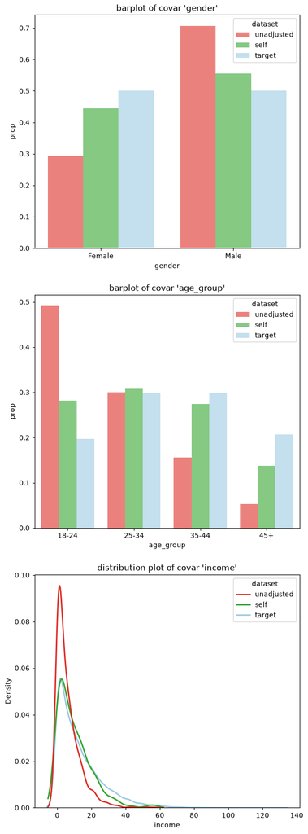

```python
adjusted_ipw.covars().plot(library = "seaborn", dist_type = "kde")
```

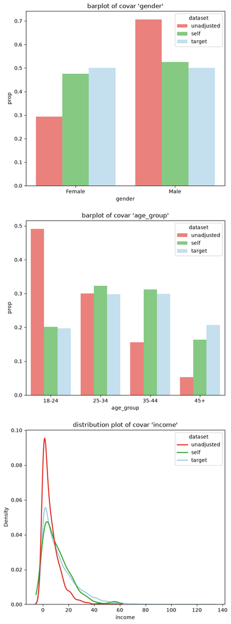

```python
adjusted_cbps.covars().plot(library = "seaborn", dist_type = "kde")
```

We can also use different plots, using the seaborn library, for example with the "kde" dist_type.

### Understanding the weights

And get the design effect using:

```python
print("ipw:")
print(adjusted_ipw.weights().design_effect())
print("\ncbps:")
print(adjusted_cbps.weights().design_effect())
```

```
ipw:
1.8799885035453148

cbps:
2.7543122035657928
```

# Outcome analysis

```python
print(adjusted_ipw.outcomes().summary())
adjusted_ipw.outcomes().plot()
```

```
1 outcomes: ['happiness']
Mean outcomes (with 95% confidence intervals):
source       self  target  unadjusted           self_ci         target_ci     unadjusted_ci
happiness  53.295  56.278      48.559  (52.096, 54.495)  (55.961, 56.595)  (47.669, 49.449)

Weights impact on outcomes (t_test):
           mean_yw0  mean_yw1  mean_diff  diff_ci_lower  diff_ci_upper  t_stat  p_value       n
outcome
happiness    48.559    53.295      4.736          1.312          8.161   2.714    0.007  1000.0

Response rates (relative to number of respondents in sample):
   happiness
n     1000.0
%      100.0
Response rates (relative to notnull rows in the target):
    happiness
n     1000.0
%       10.0
Response rates (in the target):
    happiness
n    10000.0
%      100.0
```

[interactive chart not shown]

```python
print(adjusted_cbps.outcomes().summary())
adjusted_cbps.outcomes().plot()
```

```
1 outcomes: ['happiness']
Mean outcomes (with 95% confidence intervals):
source       self  target  unadjusted          self_ci         target_ci     unadjusted_ci
happiness  54.366  56.278      48.559  (53.003, 55.73)  (55.961, 56.595)  (47.669, 49.449)

Weights impact on outcomes (t_test):
           mean_yw0  mean_yw1  mean_diff  diff_ci_lower  diff_ci_upper  t_stat  p_value       n
outcome
happiness    48.559    54.366      5.807          0.911         10.703   2.328     0.02  1000.0

Response rates (relative to number of respondents in sample):
   happiness
n     1000.0
%      100.0
Response rates (relative to notnull rows in the target):
    happiness
n     1000.0
%       10.0
Response rates (in the target):
    happiness
n    10000.0
%      100.0
```

[interactive chart not shown]

As we can see, CBPS has a larger design effect, but also fixes more of the ASMD and has an impact on the outcome. So there are pros and cons for each of the two methods.

# Downloading data

Finally, we can prepare the data to be downloaded for future analyses.

```python
adjusted_cbps.to_download()
```

Click here to download: /tmp/tmp_balance_out_9bc0e8e8-eba7-4e9d-abed-15e5201c7574.csv

```python
# We can prepare the data to be exported as csv - showing the first 500 charaacters for simplicity:
adjusted_cbps.to_csv()[0:500]
```

```
'id,gender,age_group,income,happiness,weight\n0,Male,25-34,6.428659499046228,26.043028759747298,6.067919231715549\n1,Female,18-24,9.940280228116047,66.88548460632677,7.268406231045273\n2,Male,18-24,2.6736231547518043,37.091921916683006,2.2276967604955167\n3,,18-24,10.550307519418066,49.3940500327100…
```

```python
# Sessions info
import session_info
session_info.show(html=False, dependencies=True)
```

[output not shown]

[output cut: 44 more lines]

```
websocket                   1.9.0
yaml                        6.0.3
zmq                         27.1.0
zoneinfo                    NA
-----
IPython             9.16.1
jupyter_client      8.9.1
jupyter_core        5.9.1
jupyterlab          4.6.3
notebook            7.6.2
-----
Python 3.12.13 (main, Jun 16 2026, 22:05:08) [GCC 13.3.0]
Linux-6.17.0-1022-azure-x86_64-with-glibc2.39
-----
Session information updated at 2026-08-15 06:46
```